# Alberta Income Support Caseload: Historic Trends and Client-Type Dynamics

Author

Literate analysis — Starter 28 (Claude Opus 4.6)

Published

April 15, 2026

```r
library(tidyverse)
library(scales)
```

## Data Ingestion

The raw CSV from Alberta Open Government uses a two-row header and embeds commas inside quoted numeric values. We skip the title row, strip the trailing empty columns, and parse `Value` as a proper numeric.

```r
raw <- read_csv(
  "../../is-aggregated-data-april-2005-sep-2025.csv",
  skip = 1,                         # drop the title row
  col_types = cols(.default = "c")  # read everything as character first
) |>
  select(1:5) |>                     # keep only meaningful columns
  set_names(c("ref_date", "geography", "measure_type", "measure", "value"))

# Parse the value column: strip spaces and embedded commas, then convert
raw <- raw |>
  mutate(
    value = str_trim(value) |> str_remove_all(",") |> as.numeric()
  )

# Parse the date: format is "YY-Mon" (e.g. "05-Apr", "25-Sep")
raw <- raw |>
  mutate(
    date = parse_date(paste0("01-", ref_date), format = "%d-%y-%b")
  )

glimpse(raw)
```

```
Rows: 3,721
Columns: 6
$ ref_date     <chr> "05-Apr", "05-May", "05-Jun", "05-Jul", "05-Aug", "05-Sep…
$ geography    <chr> "Alberta", "Alberta", "Alberta", "Alberta", "Alberta", "A…
$ measure_type <chr> "Total Caseload", "Total Caseload", "Total Caseload", "To…
$ measure      <chr> "Total Caseload", "Total Caseload", "Total Caseload", "To…
$ value        <dbl> 27969, 27894, 27720, 27680, 27702, 26896, 25899, 26042, 2…
$ date         <date> 2005-04-01, 2005-05-01, 2005-06-01, 2005-07-01, 2005-08-…
```

## Building a Unified Total Caseload Series

The dataset reports total caseload under two different labels depending on the era. Before April 2012 the measure is called **Total Caseload**; from April 2012 onward it appears as **Client Caseload Total** within the *Client Type Level* measure type. We stitch these together into one continuous monthly series.

```r
totals <- raw |>
  filter(
    (measure_type == "Total Caseload" & measure == "Total Caseload") |
    (measure_type == "Client Type Level" & measure == "Client Caseload Total")
  ) |>
  arrange(date)

cat(
  "Total series spans", format(min(totals$date), "%B %Y"),
  "to", format(max(totals$date), "%B %Y"),
  paste0("(", nrow(totals), " months)\n")
)
```

```
Total series spans April 2005 to September 2025 (246 months)
```

## Research Question 1 — What Is the Historic Trend?

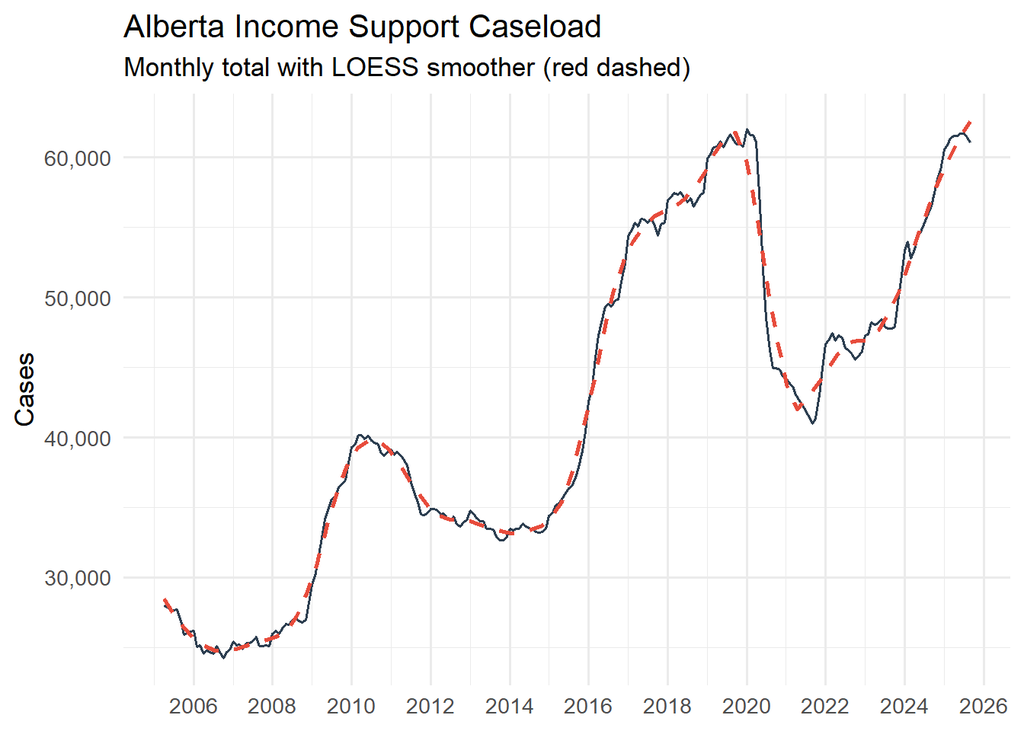

Figure 1: Monthly Income Support caseload in Alberta, April 2005 – September 2025

```r
ggplot(totals, aes(date, value)) +
geom_line(linewidth = 0.6, colour = "#2c3e50") +
  geom_smooth(method = "loess", span = 0.15, se = FALSE,
              linewidth = 0.9, colour = "#e74c3c", linetype = "dashed") +
  scale_x_date(date_breaks = "2 years", date_labels = "%Y") +
  scale_y_continuous(labels = comma) +
  labs(
    x = NULL, y = "Cases",
    title = "Alberta Income Support Caseload",
    subtitle = "Monthly total with LOESS smoother (red dashed)"
  ) +
  theme_minimal(base_size = 13)
```